# Using the GSS to Visualize People’s Opinions on Traditional Gender Roles in the United States

Asma Syed

2026-01-15

## Introduction

The **General Social Survey (GSS)** is a nationally representative survey conducted in the United States since 1972 which collects information on demographic characteristics, behaviors, and attitudes of Americans.  
This project focuses on survey questions related to **opinions on traditional gender roles**, and examines how responses vary across demographic groups.

## Research Questions

- Are attitudes on traditional gender roles associated with demographic factors?
- Does political ideology significantly predict agreement with traditional gender roles?

The demographic characteristics (explanatory variables) that were examined are described in the data dictionary. The response variables reflecting the GSS survey questions on traditional gender roles include: 1. **HUBBYWK1**: “Do you agree or disagree that a man’s job is to earn money and a woman’s job is to look after the home and family?” 2. **FAMSUFFR**: “Do you agree or disagree that all in all, family life suffers when a woman has a full-time job?”

## Data Dictionary

| Variable | Description | Categories / Notes |
| --- | --- | --- |
| BALLOT | Ballot administered with survey questions | Ballot (A= 1, B = 2, C = 3) |
| RACE | Respondent’s Race | Black, White, Other |
| AGE | Respondent’s Age | 18-89 Years |
| SEX | Respondent’s Sex | Binary (1 = Male, 2 = Female) |
| MARITAL | Marital Status | 5 categories |
| MARTYPE | Marital Type | Heterosexual, Same-Sex Marriage, Not Sure |
| INCOME | Total Family Income | 12 categories |
| HRS1 | Hours Worked Last Week | 0-89 Hours |
| WRKSTAT | Labor Force Status | 8 categories |
| DEGREE | Respondent’s Degree | Likert scale 0-5 |
| POLVIEWS | Political Views | Likert scale 1-7 |
| REGION | Respondent’s Region in US | 9 categories |
| BORN | Was Respondent Born in the US? | Binary (1 = Yes, 2 = No) |
| HUBBYWK1 | Response Variable | Likert scale 1-5 |
| FAMSUFFR | Response Variable | Likert scale 1-5 |

## Data Cleaning and Preperation

#### Study Population

The data set was extracted from the General Social Survey (GSS) Data Explorer database and variables of interest were selected after considering their possible influence on people’s attitudes towards traditional gender roles. The full data set consists of 72,390 observations and 20 variables. To focus on the 2022 survey population, the analysis was restricted to responses from that year resulting in a total of 3,544 respondents.

Because the response variables of interest were administered on one of the three GSS ballots, the data set was restricted to respondents who received that ballot. In addition, neutral responses (“Don’t know/unsure”) for the response variables **HUBBYWK1** and **FAMSUFFR** and the variable **MARTYPE** were excluded. These restrictions resulted in a sample of 803 respondents.

Data cleaning steps were performed on the study variables. Negative survey codes indicating a lack of response were assigned as missing values and the explanatory variables were re-categorized to improve interpretability.The response variables, **HUBBYWK1** and **FAMSUFFR**, were originally measured on a five-point Likert scale (1=Strongly Agree to 5 = Strongly Disagree). Neutral responses were excluded and the scale was condensed into two categories: **1** for **agree** and **2** for **disagree**.

#### Multiple Imputation For Missing Values

Missing values were addressed using multiple imputation with the `mice` package in R. All variables were converted to factors and missingness patterns were assessed. The variable **MARTYPE** had the most missing values but imputation was performed to retain these observations.

Predictive mean matching was used to generate five imputed data sets with 25 iterations which were then pooled into a single complete data set. Split plots were created for variables with missing values to confirm that the imputed distributions aligned with the observed data (figures below). The resulting data set was used for analysis, ensuring that missing values did not bias the results.

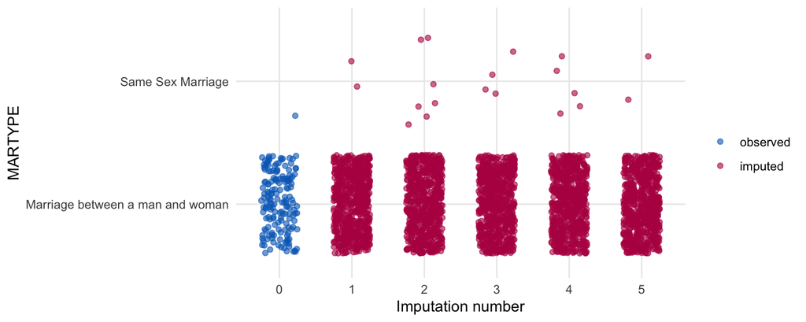

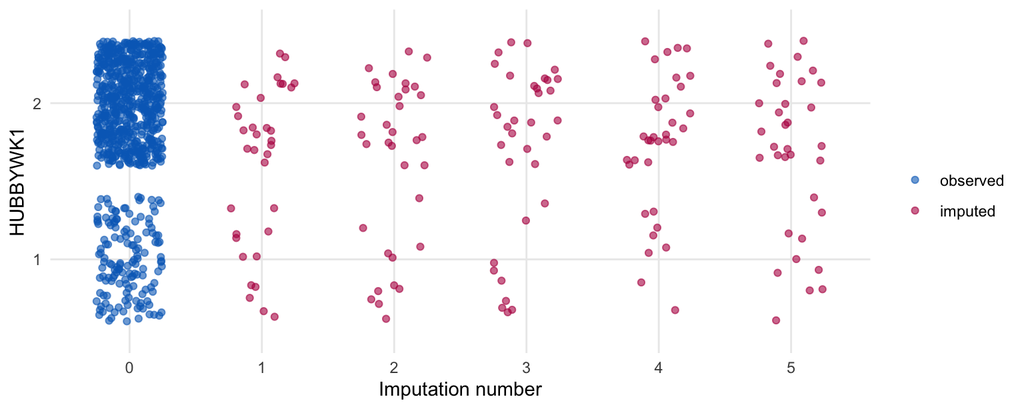

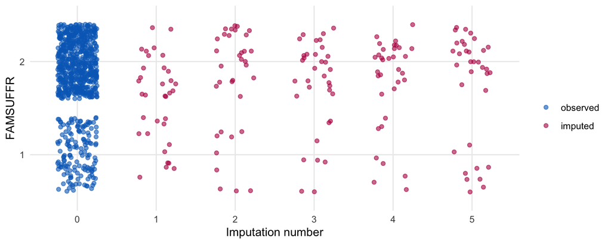

## Research Question 1

To address the research question, a logistic regression model was built with the imputed data. The first model tested the significance between the response variable **HUBBYWK1** and the explanatory variables.

Using a significance level of α = 0.05, the following variables were found to have a statistically significant relationship:

- DEGREE (Graduate) → p = 0.012
- SEX (Male) → p = 0.016
- RACE (White) → p = 0.030
- BORN (Not born in US) → p = 0.008
- REGION (South) → p = 0.039
- POLVIEWS (Slightly Liberal,Liberal,Extremely Liberal,Moderate) → p = < 0.001

The results of the Hosmer-Lemeshow Goodness of Fit test indicate that the model is a good fit for the data, since the p.value is larger than 0.05 and is close to 1.

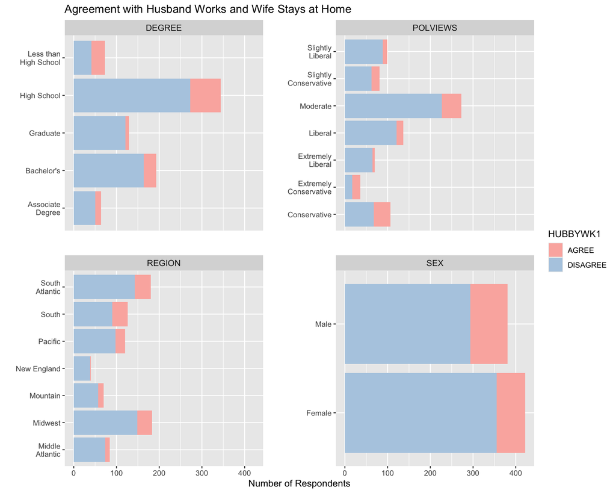

### Question 2

For the second response variable, **FAMSUFFR**, a logistic regression model was fit using the imputed data.

At a significance level of α = 0.05, the following variables were found to have a statistically significant relationship with FAMSUFFR:

- AGE (60 to 69 Years) → p.value (0.028)
- DEGREE (Graduate) → p.value (0.011)
- SEX (Male) → p.value (0.018)
- BORN (Not born in US) → p.value (0.001)
- POLVIEWS (Liberal) → p.value (0.007)
- POLVIEWS (Extremely Liberal) → p.value (0.002)
- POLVIEWS (Slightly Liberal) → p.value (0.038)

The Hosmer Lemeshow Goodness of fit test indicated that the model fit the data (p > 0.05).

Stacked bar charts were created with the statistically significant variables:

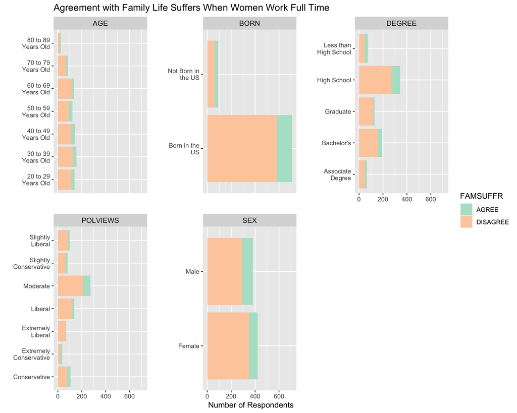

Consistent with the results from the first model, the variable **DEGREE** remained a significant predictor: respondents with a graduate degree were more likely to disagree with the survey statement. **POLVIEWS** also showed a strong association with **FAMSUFFR**. Respondents identifying with liberal political views were more likely to disagree with the statement: family life suffers when women work full time, compared to those identifying as conservative, who had mixed responses.

## Conclusion

This study examined attitudes towards traditional gender roles using data from the 2022 General Social Survey and whether demographic characteristics and political ideology relate to these attitudes. Across both models, political ideology emerged as the most consistent predictor, which respondents identifying as liberal most likely to disagree with traditional gender roles. Educational attainment also showed a meaningful association, as respondents with graduate degrees were more likely to oppose traditional gender norms. This analysis is subject to several limitations. The GSS is cross-sectional, which limits interpretation to a proportion of the population and responses are self reported. Additionally, multiple imputation for missing values may introduce some uncertainty despite checks indicating reasonable model fit. Future research could explore longitudinal trends in attitudes towards gender roles or examine interactions between political ideology and other demographics in greater depth.